# Einführung in Web Scraping

[Ueli Reber](https://uelireber.ch)

Version vom 18. Mai 2020

Diese Einführung in R is inspiriert von und basiert zum Teil auf Arbeiten von [Rudolf Farys](http://www.soz.unibe.ch/ueber_uns/personen/dr_farys_rudolf/index_ger.html), [Ramnath Vaidyanathan](https://github.com/ramnathv), [Iegor Rudnytskyi](https://irudnyts.github.io/), [Hadley Wickham](http://hadley.nz/), [Garrett Grolemund](https://github.com/garrettgman), [Selva Prabhakaran](http://r-statistics.co/), Matt w. Loftis, [Julia Silge](https://juliasilge.com/), [David Robinson](http://varianceexplained.org/), [Andreas Niekler](http://asv.informatik.uni-leipzig.de/staff/Andreas_Niekler), [Gregor Wiedemann](http://www.gregor-wiedemann.de/) und anderen Personen aus der R-Community.

## Präambel

Web Scraping ist eine verlockende, aber auch etwas dunkle Kunst. Nur weil wir etwas können, sollten wir es nicht unbedingt auch tun. Insbesondere bei personenbezogenen Daten (z.B. Rangliste Grand Prix von Bern) und Social-Media-Daten (z.B. Posts von Facebook-Freund*innen) ist höchste Vorsicht und Rücksicht geboten. Kritisch sind aber auch urheberrechtlich geschützte Daten (z.B. Bilder, Musik) sowie Daten, die durch die “Terms of Services” (TOS) eines Anbieters geschützt sind (vgl. Freelon, 2018).

Viele Betreiber*innen von Webseiten möchten zudem nicht, dass automatisiert Daten von ihrer Webseite gezogen werden. Entweder aus Performance-Gründen (Überlastung des Servers) oder weil es ihr Geschäftsmodell untergräbt (Werbung, Quoten).

Auf der sicheren Seite und gute Bürger*innen sind wir, wenn wir uns an folgende Grundsätze halten:

- Kein Scraping von passwortgeschützten Webseiten
- `robots.txt` beachten ([Robots Exclusion Standard](https://de.wikipedia.org/wiki/Robots_Exclusion_Standard)), z.B. unibe.ch/robots.txt
- Keine Exzesse: Scraping nur in verträglichen Dosen!
- Alternativen prüfen
  - Weshalb nicht fragen, wenn der gewünschte Inhalt in einer Datenbank liegt?
  - Wenn es eine API gibt: API verwenden!

## Was ist Web Scraping?

Daten können auf ganz unterschiedliche Weise aus dem Web gezogen werden.

- Manueller Download: z.B. [Die Frauenrepräsentation auf kantonaler und nationaler Ebene](https://www.bfs.admin.ch/bfs/de/home/statistiken/kataloge-datenbanken/tabellen.assetdetail.7926143.html) (Bundesamt für Statistik)
- Massendownload: z.B. [Wortlautprotokolle Grosser Rat Bern](https://www.gr.be.ch/gr/de/index/sessionen/sessionen/sessionen-2020/fruehlingssession_2020.html) (eventuell mit [Download Manager](https://en.wikipedia.org/wiki/Comparison_of_download_managers))
- [APIs](https://de.wikipedia.org/wiki/Programmierschnittstelle), z.B. Twitter
- Scraping mit eigenem Code
  - Statische, gut strukturierte Webseite
  - Statische, schlecht strukturierte Webseite
  - Dynamische Webseiten

Wir werden uns im Folgenden auf das Scraping von statischen, (mehr oder weniger) gut strukturierten Webseiten konzentrieren.

Dieses Scraping umfasst zwei wesentliche Schritte: (1) dem Download von Webseiten und (2) dem Herausdestillieren von (Text-)Daten aus diesen (dem sogenannten Parsing). Herausfordernd ist dabei nicht der Download, sondern das Parsing.

In der Regel handelt es sich bei statischen Webseiten um hierarchisch strukturierte Textdateien, die sowohl von Menschen als auch von Maschinen lesbar sind. Geschrieben sind Webseiten meistens in [HTML](https://de.wikipedia.org/wiki/Hypertext_Markup_Language) (Hypertext Markup Language) oder [XML](https://de.wikipedia.org/wiki/Extensible_Markup_Language) (Extensible Markup Language). Dabei handelt es sich um sogenannte Auszeichnungssprachen, die Eigenschaften, Zugehörigkeit und Darstellung von Text (und Daten) mittels Tags definieren.

Tags umschliessen Inhalte nach dem Muster `<tag>` und `</tag>`. Durch die Verschachtelung von Tags entsteht eine klare hierarchische Struktur im Dokument. Eine Webseite kann man sich daher als ein mehr oder weniger stark verästelter Baum vorstellen.

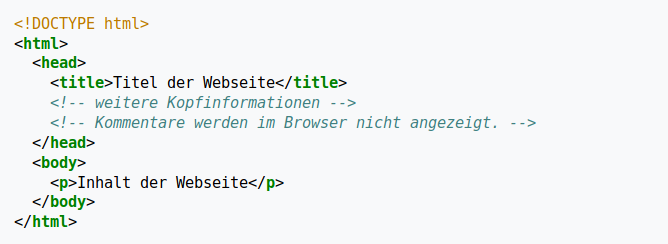

Quelle: [Wikipedia](https://de.wikipedia.org/wiki/Hypertext_Markup_Language#HTML-Struktur)

Meistens interessieren wir uns aber nicht für einzelne Äste einer Webseite, sondern für bestimmte Inhalte (z.B. Überschriften, Tabellen, Nutztext, Links), die an unterschiedlichen Stellen im Baum vorkommen können. Diese müssen wir beim Parsing mit Hilfe von R aus HTML/XML-Dokumenten extrahieren. Dabei hilft uns, dass gleich aussehende Inhalte (z.B. Überschriften) meistens zur gleichen [CSS](https://de.wikipedia.org/wiki/Cascading_Style_Sheets)-Klasse (Cascading Style Sheets) gehören (mit Hilfe von CSS können Inhalte in Klassen zusammengefasst werden, für die sich dann Erscheinungsmerkmale definieren lassen, z.B. Schriftgrösse, Schriftart, Position). Anstatt für jeden gewünschten Inhalt einzeln durch den gesamten Baum zu navigieren, können wir sie über ihre CSS-Klasse direkt und alle auf einmal extrahieren.

Beim Web Scraping brauchen wir R also für folgende Arbeitsschritte:

1. Herunterladen von HTML/XML-Dokumenten (Webseiten) aus dem Web
2. Aufgliedern der Dokumente in ihre Baumstruktur
3. In der Baumstruktur (mit Hilfe von CSS) zum gewünschten Inhalt navigieren
4. Diesen Inhalt als R-Daten-Objekt extrahieren
5. R-Daten-Objekt für Analyse aufbereiten

## Basics

Bei allen fünf Schritten hilft uns das sehr praktische `tidyverse`-Package [rvest](http://rvest.tidyverse.org/).

```r
# Package installieren
install.packages("rvest")
# und gleich laden
library(rvest)

# ausserdem brauchen wir die übrigen Packages aus dem tidyverse
library(tidyverse)
```

Möchten wir uns zum Beispiel die letzten [Medienmitteilungen der Uni Bern](https://www.unibe.ch/aktuell/medien/media_relations/medienmitteilungen/2020/index_ger.html) analysieren, können wir sie uns wie folgt beschaffen.

```r
# 1. Herunterladen der Webseite aus dem Web
# 2. Aufgliedern des Dokuments in seine Baumstruktur (in einem R-Objekt)
mm_unibe <- read_html("https://www.unibe.ch/aktuell/medien/media_relations/medienmitteilungen/2020/index_ger.html")
```

Bei der Navigation mittels CCS helfen uns die Funktionen `html_nodes()` und `xml_nodes()`. Mit ihnen können wir den Inhalt einer geladenen Webseite nach einer bestimmten CSS-Klassen filtern.

Die richtige Klasse finden wir, indem wir den Seitenquelltext anschauen oder das super praktische Tool [SelectorGadget](https://selectorgadget.com/) verwenden.

SelectorGadget ist ein Tool, mit dem wir interkativ die CSS-Klasse der Elemente identifizieren können, die wir extrahieren möchten. Siehe [hier](http://rvest.tidyverse.org/articles/selectorgadget.html) für eine ausführlichere Anleitung von SelectorGadget und [hier](https://www.khanacademy.org/computing/computer-programming/html-css#intro-to-css) für eine etwas ausführlichere Einführung in CSS.

Die eigentliche Information können wir dann mit `html_text()` (Text), `html_name()` (Name des Tags), `html_attr()` (Attribut, z.B. Hyperlink) extrahieren. Ein Spezialfall sind Tabellen. Sie können mit `html_table()` direkt ausgelesen werden.

```r
# 3. In der Baumstruktur (mit Hilfe von CSS) zum gewünschten Inhalt navigieren
# 4. Inhalte als R-Daten-Objekt extrahieren

# Datum der Medienmitteilung
datum <- mm_unibe %>%
  html_nodes(".title-main") %>%
  html_text()
# Titel
titel <- mm_unibe %>%
  html_nodes(".title-sub") %>%
  html_text()
# Lead
lead <- mm_unibe %>%
  html_nodes(".noborderbottom p") %>%
  html_text()
# Link zur ganzen Mitteilung
link <- mm_unibe %>%
  html_nodes(".title a") %>%
  html_attr("href")

# 5. R-Daten-Objekt für Analyse aufbereiten
mm_unibe_df <- data.frame(datum = datum,
                          titel = titel,
                          lead = lead,
                          link = link,
                          stringsAsFactors = FALSE)
glimpse(mm_unibe_df)
```

##### Aufgabe: Web Scraping I

###### Aufgabe

1. Programmiere dir deinen eigenen [aare.guru](https://aare.guru/#bern), der dich über die aktuelle Wassertemperatur in der Schönau informiert. Nimm die Messwerte direkt von [hier](https://www.hydrodaten.admin.ch/de/2135.html).
   - Verwende dafür die `rvest`-Funktion `html_table()`. Der Output ist eine Liste mit Data Frames. Jeder Data Frame (bzw. jedes Listenelemten) ist eine Tabellen der eingelesenen Webseite (das können viele sein!). Zur Erinnerung: Elemente können Listem mit doppelten eckigen Klammern `[[]]` entnommmen werden.
   - Wenn du die Temperatur extrahiert hast, kannst du mit Hilfe von `paste` oder `paste0()` einen Satz formulieren, z.B. “D’Aare isch ize 12 Grad warm.”
2. Erweitere deinen aare.guru, damit er dir auch Auskunft über die aktuelle Abflussmenge gibt. Zudem soll er warnen, wenn Hochwassergefahr besteht ([Gefahrenstufe](https://www.hydrodaten.admin.ch/de/die-5-gefahrenstufen-fur-hochwasser.html) 2 oder höher). Benutze eine `if-else`-Anweisung, um die Antwort von deinem aare.guru zu steuern. Ist der aktuelle Abfluss grösser als 360 $m^3 / s$ soll dir dein aare.guru von einem Schwumm abraten. Ist die Abflussmenge jedoch kleiner, steht einem Schwumm nichts im Weg.
3. Dein aare.guru soll dir auch die aktuelle Lufttemperatur angeben. Nimm sie von [hier](https://www.bodenmessnetz.ch/messwerte/aktuelle_daten/zollikofen) (mittlere Spalte in der rechten Tabelle). Bau die Information in deine mit Hilfe von `paste()` formulierte Guru-Antwort ein.

###### Lösung

```r
# 1. Wassertemperatur
aare_html <- read_html("https://www.hydrodaten.admin.ch/de/2135.html")

aare_tables <- html_table(aare_html)

aare_messw <- aare_tables[[1]]
temp <- aare_messw[1, 4]

paste0("D'Aare isch ize ", temp, " Grad warm.")

# 2. Abflussmenge und Gefahrenstufe
abfl <- aare_messw[1, 2]

if (abfl < 360) {
  paste0("D'Aare isch ize ", temp, " Grad warm. D'Wassermängi isch gmüetlech (", abfl, " Kubikmeter pro Sekunde).")
} else {
  paste("D'Aare isch ize ", temp, "Grad warm. D'Wassermängi isch gförchig (", abfl, " Kubikmeter pro Sekunde). Das isch z'viu füre Schwumm.")
}

# 3 Lufttemperatur
temp_html <- read_html("https://www.bodenmessnetz.ch/messwerte/aktuelle_daten/zollikofen")

temp_tables <- html_table(temp_html, fill = TRUE)

temp_luft_df <- temp_tables[[2]]
temp_luft <- temp_luft_df[2, 2]

if (abfl < 360) {
  paste0("D'Aare isch ize ", temp, " Grad warm. Dusse isches ", temp_luft, " Grad.",
         " D'Wassermängi isch gmüetlech (", abfl, " Kubikmeter pro Sekunde).")
} else {
  paste0("D'Aare isch ize ", temp, " Grad warm. Dusse isches ", temp_luft, " Grad.",
         " D'Wassermängi isch gförchig (", abfl, " Kubikmeter pro Sekunde). Das isch z'viu füre Schwumm.")
}
```

## Strings

Das Herausdestillieren der gewünschten Information aus einer Webseite ist oft tricky. In vielen Fällen kommt man nur mit der CSS-Klasse alleine nicht zum Ziel, da die gewünschte Information (z.B. Datum, Zeit, Name) Teil einer längeren Zeichenkette, einem String, ist.

Möchten wir von der Startseite von Wikipedia beispielsweise auslesen, wer kürzlich an welchem Datum und in welchem Alter verstorben ist, geht das nicht mir der CSS-Klasse. Wir müssen die Informationen (Name, Alter, Grund für Bekanntheit, Todesdatum) den Strings entnehmen, die wir mittels CSS-Klase erhalten.

```r
wiki_html <- read_html("https://de.wikipedia.org/wiki/Wikipedia:Hauptseite")

wiki_nec <- wiki_html %>%
  html_nodes("#mf-nec li") %>%
  html_text()
wiki_nec
```

Zentrales Werkzeug dabei sind sogenannte [Regular Expressions](https://stringr.tidyverse.org/articles/regular-expressions.html), auch Regex genannt. Mit den richtigen Regex, den passenden Funktionen und genügend Geduld lassen sich fast alle Informationen aus Strings extrahieren.

### Regular Expressions (Regex)

Regex ist eine Sprache mit der sich syntaktische Muster beschreiben lassen. Mit Hilfe von Funktionen aus dem [stringr](https://stringr.tidyverse.org/)-Package (tidyverse) können wir anschliessend in Strings nach diesen Mustern suchen.

```r
x <- c("apfel", "birne", "banane", "melone")

# Exakter Match
str_view(x, "an")

# Ein Punkt . ist ein Platzhalter für ein beliebiges Zeichen
# (ausser einer neuen Zeile)
str_view(x, ".n.")
```

Beachte: wenn wir nach einen Punkt `.` suchen wollen, müssen wir in der Regex festhalten, dass der Punkt `.` als Zeichen und nicht als Platzhalter gelesen werden soll. Dafür brauchen wir ein **Escape**-Zeichen vor dem Punkt. In dem Fall ist das ein linksseitiger Schrägstrich `\`. Um also nach einem Punkt `.` zu suchen, müssen wir die Regex `\.` verwenden.

Leider brauchen wir den Backslash `\` in R aber schon als Escape-Zeichen für bestimmte Symbole in Strings (z.B. `"\n"` für eine neue Zeile oder `"\u00b5"` für das Mikro-Zeichen $µ$). Um nach einem Punkt `.` zu suchen, brauchen wir in R deshalb zwei Schrägstrichte vor dem Punkt: `\\.`

```r
x <- c("abc", "a.b", "cb\\")

# Suche nach einem Punkt .
str_view(x, "\\.")

# Linksseitiger Schrägstrich \ (Backslash)
str_view(x, "\\\\")
```

Standardmässig finden Regex die Muster in allen Teilen eines Strings. Oft steht ein Muster aber am Anfang oder Ende eines Strings. In dem Fall müssen wir die Regex **verankern**.

- `^`: Verankerung am Anfang
- `$`: Verankerung am Ende

```r
x <- c("apfel", "roter apfel", "apfel gross", "roter apfel gross")

# ohne Verankerung
str_view(x, "apfel")

# Verankerung am Anfang
str_view(x, "^apfel")

# Verankerung am Ende
str_view(x, "apfel$")

# Verankerung am Anfang und am Ende
str_view(x, "^apfel$")
```

Anstelle des Punkts `.` können für bestimmte Zeichen auch andere Platzhalter verwendet werden.

- `\d`: Platzhalter für eine Zahl
- `\s`: Platzhalter für ein Leerzeichen (Leerschlag, Tab, neue Zeile)
- `[abc]`: Platzhalter für a, b oder c
- `[^abc]`: Platzhalter für alles ausser a, b, c
- `(ab|cd)`: Platzhalter für ab oder cd

Friendly reminder: Für `\d` und `\s` braucht es in R einen zweiten Schrägstrich, also `\\d` oder `\\s`.

Eckige Klammern `[]` können auch eine gute Alternative zum Schrägstriche-Escape von Sonderzeichen sein, also beispielsweise `[.]` anstatt `\\.`. Das funktioniert für `$`, `.`, `|`, `?`, `*`, `+`, `(`, `)`, `[` und `{`, nicht aber für `]`, `\`, `^` und `-`.

```r
x <- c("aepfel", "äpfel", "3 aepfel", "gr. aepfel")

# Platzhalter für Zahl: \d
str_view(x, "\\d")

# Platzhalter für Leerzeichen: \s
str_view(x, "\\s")

# Eckige Klammern
str_view(x, "gr[.]")

# Runde Klammer
str_view(x, "(ae|ä)pfel")
```

Weiter gibt es in Regex die Möglichkeit zu kontrollieren, wie viel Mal ein Zeichen wiederholt wird.

- `?`: 0 oder 1
- `+`: 1 oder mehr
- `*`: 0 oder mehr

Alternativ können die Anzahl Wiederholungen auch genau definiert werden.

- `{n}`: genau n
- `{n,}`: n oder mehr
- `{,m}`: maximal m
- `{n,m}`: zwischen n und m

```r
x <- "In römischen Zahlen ist 1888 das längste Jahr: MDCCCLXXXVIII"

# Wiederholungen
str_view(x, "CC?")
str_view(x, "CC+")

str_view(x, "C{2}")
str_view(x, "C{2,}")
```

Mit runden Klammern `()` lassen sich Gruppen bilden. Die Zeichen innerhalb einer Gruppe sind nummeriert, sie müssen also exakt in dieser Reihenfolge vorkommen, damit es einen “Match” gibt. Gruppen lassen sich mit Rückbezügen (“backreferences”) wiederholen, zum Beispiel `\1` oder `\2`.

```r
# Alle Früchte, die ein sich wiederholendes, aber beliebiges Buchstabenpaar enthalten
str_view(fruit, "(..)\\1", match = TRUE)
```

Beim Web Scraping schliesslich besonders wichtig sind sogenannte **Lookarounds**, da sie uns helfen den Beginn und das Ende eines Musters festzulegen (wenn diese nicht am Zeilenanfang oder -ende stehen). Mit Lookarounds lassen sich nach bestimmten Mustern suchen, die wir als Start- oder Endpunkt von dem festlegen möchten, was uns eigentlich interessiert. Wir können also zum Beispiel nach Informationen suchen, die in einer Klammer stehen.

Unterschieden werden positive und negative Lookarounds. Einen *negativen Lookahead* brauchen wir, wenn wir nach einem Muster suchen, das *nicht* von einem bestimmten anderen gefolgt wird. Möchten wir zum Beispiel ein `q` auf das kein `u`folgt, können wir schreiben `q(?!u)`. Möchten wir hingenen ein `q` auf das ein `u` folgt, brauchen wir einen *positiven Loookahead*: `q(?=u)`.

Mit *negativen/positiven Lookbehinds* funktioniert das auch in die andere Richtung. Möchten wir ein `b`, vor dem kein `a` steht, können wir das so formulieren: `(?<!a)b` (negativer Lookbehind). Soll hingegen ein `a` vor dem `b` stehen, können wir den positiven Lookbehind `(?<=a)b` verwenden.

```r
# negativer Lookahead
str_view(fruit, "e(?!i)", match = TRUE)
# positiver Lookahead
str_view(fruit, "e(?=i)", match = TRUE)

# negativer Lookbehind
str_view(fruit, "(?<!q)u", match = TRUE)
# positiver Lookbehind
str_view(fruit, "(?<=q)u", match = TRUE)
```

Das Herstellen von richtigen Regex kann sehr nervenaufreibend sein. Hilfreich sind unter anderem das [Cheat Sheet](https://github.com/rstudio/cheatsheets/blob/master/strings.pdf) und die [Website](https://stringr.tidyverse.org/articles/regular-expressions.html) des `stringr`-Package sowie die sehr gute Website [Regular-Expression.info](https://www.regular-expressions.info/quickstart.html).

Ausserdem gibt es Packages, wie beispielsweise [RVerbalExpressions](https://rverbalexpressions.netlify.com/reference/index.html), die einem beim Herstellen von Regex helfen können.

```r
# Package installieren
install.packages("RVerbalExpressions")
# und laden
library(RVerbalExpressions)

# aepfel und äpfel
x <- c("aepfel", "äpfel", "3 aepfel", "gr. aepfel")

regx <- rx() %>%
  rx_either_of("ae", "ä") %>% # (ae|ä)
  rx_find(value = "pfel") # genauer Match von pfel
regx
str_view(x, regx)

regx <- rx() %>%
  rx_seek_prefix(" ") %>% # positiver Lookbehind für Leerschlag
  rx_anything() # beliebig viele beliebige Zeichen bis Zeilenende
regx
str_view(x, regx)
```

##### Aufgabe: Regular Expressions

###### Aufgabe

1. Wie würdest du nach `.\-` suchen? Tipp: Als String muss `.\-` in R als `".\\-"` eingegeben werden, also z.B. `must <- c(".\\-")`
2. Was für eine Muster beschreibt die Regex `\..\..\..`? Wie müsstest du das in R schreiben?
3. Finde im Korpus `stringr::words` alle Wörter, die
   1. mit “y” beginnen.
   2. mit “x” enden.
   3. genau drei Buchstaben haben.
   4. sieben oder mehr Buchstaben haben.
   5. mit einem Vokal beginnen.
   6. mit `ed` enden, aber nicht mit `eed`.
   7. auf `ing` oder `ise` enden.
   8. drei oder mehr Vokale hintereinander enthalten.

Tipp: Verwende in `str_view()` die Option `match = TRUE` um nur jene Strings anzuzeigen, die dem Kriterium entsprechen.

###### Lösung

```r
# 1. Sequenz `\-
must <- c(".\\-")
str_view(must, "\\.\\\\-")

# 2. Regex \..\..\..
# Muster: z.B. ".a.b.c" oder ".3.4.5"
# Schreibweise in R: "\\..\\..\\.."
x <- c("a.b.c", ".d.e.f", "1.2.3.4.5")
str_view(x, "\\..\\..\\..")

# 3. Korpus
str_view(stringr::words, "^y", match = TRUE) # mit "y" beginnen
str_view(stringr::words, "x$", match = TRUE) # mit "x" enden
str_view(stringr::words, "^.{3}$", match = TRUE) # genau drei Buchstaben
str_view(stringr::words, ".{7,}", match = TRUE) # sieben oder mehr Buchstaben
str_view(stringr::words, "^[aeiou]", match = TRUE) # mit einem Vokal beginnen
str_view(stringr::words, "[^e]ed$", match = TRUE) # mit ed, aber nicht eed enden
str_view(stringr::words, "i(ng|se)$", match = TRUE) # auf ing oder ise enden
str_view(stringr::words, "[aeiou]{3,}", match = TRUE) # auf ing oder ise enden
```

### Funktionen

Für die Arbeit mit Strings und Regex können wir Funktionen aus dem [stringr](https://stringr.tidyverse.org/)-Package verwenden. Das hilfreiche Cheat Sheet findest du [hier](https://github.com/rstudio/cheatsheets/blob/master/strings.pdf). Für uns wichtige `stringr`-Funktion sind:

- `str_detect()`: prüfen, ob ein bestimmtes Muster in einem String vorkommt (gibt TRUE/FALSE zurück)
- `str_extract()` und `str_extract_all()`: ein bestimmtes Muster aus einem String extrahieren (einmal/alle)
- `str_subset()`: gibt aus einem Vektor nur jene Strings zurück, die ein bestimmtes Muster enthalten
- `str_trim()`: Links und/oder rechts Leerzeichen von einem String abschneiden
- `str_replace()` und `str_replace_all()`: In einem String ein bestimmtes Muster durch ein anderes ersetzten
- `str_to_lower()`: alle Buchstaben eines Strings zu Kleinbuchstaben machen
- `str_split()` und `str_split_fixed()`: Ein String bei einem bestimmten Muster in Teile zerschneiden
- `str_c()`: `stringr`-Alternative zu `paste()`

Mit diesen Funktionen und den passenden Regex können wir nun die gewünschen Informationen aus den Wikipedia-Strings extrahieren.

```r
library(rvest)
library(RVerbalExpressions)

wiki_html <- read_html("https://de.wikipedia.org/wiki/Wikipedia:Hauptseite")

wiki_nec <- wiki_html %>%
  html_nodes("#mf-nec li") %>%
  html_text()
wiki_nec

# Namen
# Hinweis: "lazy" matcht den kürzest möglichen String, "greedy" den längsten (default)
name_rx <- rx() %>%
  rx_start_of_line() %>%
  rx_anything(mode = "lazy") %>%
  rx_seek_suffix(" (")
name <- str_extract(wiki_nec, name_rx)

# Alter
age_rx <- rx() %>%
  rx_seek_prefix("(") %>%
  rx_digit() %>%
  rx_multiple(min = 0, max = 2) %>%
  rx_seek_suffix(")")
age <- str_extract(wiki_nec, age_rx)

# Grund für Bekanntheit
prom_rx <- rx() %>%
  rx_seek_prefix("), ") %>%
  rx_anything(mode = "lazy") %>%
  rx_seek_suffix(" (")
prom <- str_extract(wiki_nec, prom_rx)

# Todesdatum
date_rx <- rx() %>%
  rx_digit() %>%
  rx_multiple(min = 0, max = 2) %>%
  rx_find(value = ".") %>%
  rx_whitespace() %>%
  rx_word()
date <- wiki_nec %>%
  str_extract(date_rx) %>%
  str_c("2020", sep = " ")

wiki_nec_df <- data.frame(date = date,
                          age = as.numeric(age),
                          name = name,
                          prom = prom,
                          stringsAsFactors = FALSE)
```